# Predicting Car Crash Injury Severity Using Naive Bayes Classification

## Analysis

Now, with our features selected we can implement the classifier.

The core of a Naive Bayes classifier is a table of probabilities for each value of every feature given a specific event. In our case the event is the injury severity.

To apply the model we select the probability associated with each feature's value in the test data set, then aggregate them to determine the likelyhood of each event.

### Understanding the Data

Histograms can be a good way to help us get a feel for our data. They allow us to quickly see how common certain values are for our various features. Especially interesting is when we look at how a particular event effects these counts.

Take "Vehicle Impact Location" for example. When some kind of injury is present the chance of the collision being head on is *dramatically* higher than if there was no apparent injury.

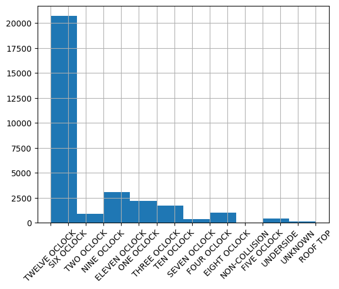

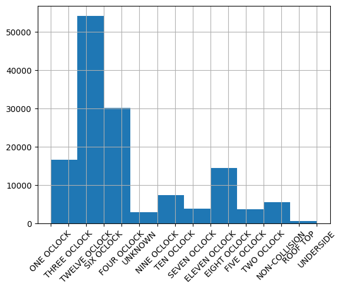

```python
import matplotlib.pyplot as plt

plt.xticks(rotation=45)
plt.figure(1)
ALL[ALL["Injury Severity"] != "NO APPARENT INJURY"]["Vehicle First Impact Location"].hist()

plt.figure(2)
plt.xticks(rotation=45)
ALL[ALL["Injury Severity"] == "NO APPARENT INJURY"]["Vehicle First Impact Location"].hist()
```

### Implementing the Classifier

In the previous section we look at the probability of "Vehicle Impact Location" being "TWELVE OCLOCK" when injury severity was "NO APPARENT INJURY" versus when it was not. This basic idea is the core of multinomial naive bayes classification algorithm.

We want to know the probability of a given feature's value in the event of "NO APPARENT INJURY", "POSSIBLE INJURY", etc. so that we can apply these probabilities to our testing set.

```python
from dataclasses import dataclass

# We'll use this dataclass to store information about the training sets, usefull when running the model
@dataclass
class CrashModel:
    counts: pd.DataFrame
    probabilities: pd.DataFrame
    categ_probabilities: pd.Series

def train(training_data):
    # this dictionary will map feature name -> feature value count
    counts_dict = {}

    # we want the value counts of each feature's values within given a specific injury severity
    groups = training_data.groupby("Injury Severity")
    for c in FEATURES:
        # get the value counts
        counts_dict[c] = groups[c].value_counts(dropna=False).unstack(fill_value=0)

        # if a specific value wasn't in training set, but is in the dataset set its count to zero
        for v in ALL[c].unique():
            if v not in counts_dict[c].columns:
                counts_dict[c][v] = 0

    # create a multi-level data frame from the counts.
    counts = pd.concat(counts_dict, axis=1)

    # calculate the probability of each value appearing at the given injury level
    # notice we add 1 to both sides of the fraction.
    # This is called "Laplace Smoothing", it eliminates zero probabilities in the result.
    probabilities = counts.apply(lambda col: (col + 1) / (col.sum() + 1), axis="columns")

    # calculate the chance of any giving record falling it a specific injury severity
    categ_probabilities = training_data["Injury Severity"].value_counts() / training_data.size
    categ_probabilities.index.name = "Injury Severity"
    return CrashModel(
        counts = counts,
        probabilities = probabilities,
        categ_probabilities = categ_probabilities)
# let's see an example of the table
train(ALL.sample(frac=.25)).probabilities
```

| Injury Severity | First Harmful Event ANIMAL | First Harmful Event BACKING | First Harmful Event BICYCLE | First Harmful Event DOWNHILL RUNAWAY | First Harmful Event FELL JUMPED FROM MOTOR VEHICLE | First Harmful Event FIXED OBJECT | First Harmful Event IMMERSION | First Harmful Event JACKKNIFE | First Harmful Event OFF ROAD | First Harmful Event OTHER | First Harmful Event OTHER CONVEYANCE | First Harmful Event OTHER NON COLLISION | First Harmful Event OTHER OBJECT | First Harmful Event OTHER PEDALCYCLE | First Harmful Event OTHER VEHICLE | First Harmful Event OVERTURN | First Harmful Event PARKED VEHICLE | First Harmful Event PEDESTRIAN | First Harmful Event RAILWAY TRAIN | First Harmful Event SPILLED CARGO | First Harmful Event THROWN OR FALLING OBJECT | First Harmful Event U-TURN | First Harmful Event UNITS SEPARATED | First Harmful Event UNKNOWN | First Harmful Event NaN | First Harmful Event EXPLOSION OR FIRE | Lane Direction East | Lane Direction North | Lane Direction South | … |
| --- | --- | --- | --- | --- | --- | --- | --- | --- | --- | --- | --- | --- | --- | --- | --- | --- | --- | --- | --- | --- | --- | --- | --- | --- | --- | --- | --- | --- | --- | --- |
| FATAL INJURY | 0.000717 | 0.000717 | 0.000717 | 0.000717 | 0.000717 | 0.010753 | 0.000717 | 0.000717 | 0.002151 | 0.000717 | 0.000717 | 0.000717 | 0.000717 | 0.000717 | 0.017921 | 0.001434 | 0.000717 | 0.000717 | 0.000717 | 0.000717 | 0.000717 | 0.000717 | 0.000717 | 0.000717 | 0.000717 | 7.168459e-04 | 0.008602 | 0.008602 | 0.011470 | … |
| NO APPARENT INJURY | 0.000177 | 0.000035 | 0.000196 | 0.000002 | 0.000004 | 0.001935 | 0.000003 | 0.000002 | 0.000173 | 0.000062 | 0.000034 | 0.000028 | 0.000126 | 0.000009 | 0.023566 | 0.000029 | 0.002097 | 0.000749 | 0.000003 | 0.000008 | 0.000009 | 0.000005 | 0.000003 | 0.000035 | 0.000142 | 8.417785e-07 | 0.005409 | 0.008047 | 0.007500 | … |
| POSSIBLE INJURY | 0.000088 | 0.000014 | 0.000020 | 0.000007 | 0.000027 | 0.002337 | 0.000007 | 0.000007 | 0.000305 | 0.000075 | 0.000020 | 0.000027 | 0.000102 | 0.000014 | 0.025604 | 0.000081 | 0.000535 | 0.000115 | 0.000007 | 0.000014 | 0.000014 | 0.000007 | 0.000007 | 0.000027 | 0.000122 | 6.775297e-06 | 0.005752 | 0.008659 | 0.008252 | … |
| SUSPECTED MINOR INJURY | 0.000157 | 0.000020 | 0.000059 | 0.000010 | 0.000020 | 0.003141 | 0.000010 | 0.000010 | 0.000313 | 0.000098 | 0.000039 | 0.000108 | 0.000137 | 0.000010 | 0.024294 | 0.000176 | 0.000646 | 0.000127 | 0.000010 | 0.000020 | 0.000068 | 0.000020 | 0.000010 | 0.000029 | 0.000127 | 9.784257e-06 | 0.005919 | 0.009050 | 0.007994 | … |
| SUSPECTED SERIOUS INJURY | 0.000091 | 0.000091 | 0.000273 | 0.000091 | 0.000182 | 0.005645 | 0.000182 | 0.000091 | 0.000637 | 0.000182 | 0.000091 | 0.000182 | 0.000455 | 0.000091 | 0.020759 | 0.000091 | 0.001275 | 0.000182 | 0.000091 | 0.000091 | 0.000091 | 0.000091 | 0.000091 | 0.000091 | 0.000546 | 9.104980e-05 | 0.005554 | 0.008923 | 0.008377 | … |

Finally, we'll apply the model.

```python
def select_probabilities(test_feature_column, model):
    """Select the probabilities for each value of a single feature from the test set, using model"""
    def get_probabilities(injury_categ_row):
        # given a specific injury category row, select the given feature values from it for test_feature_column
        # then convert the result to a dataframe, and reindex using the original test feature column.
        # changing the index will allow us to merge these probabilities back to the original dataframe later
        return injury_categ_row.loc[test_feature_column.name][test_feature_column.values].to_frame(injury_categ_row.name).set_index(test_feature_column.index)

    # x is now a series of dataframes
    x = model.probabilities.apply(lambda p: get_probabilities(p), axis="columns")
    x = pd.concat(x.values, axis="columns")
    x.name = test_feature_column.name
    return x

def predict(test_set, model):
    # for each feature, select the probabilities from the model
    # join the result into a multi-level dataframe that maps (ID, Injury Severity) -> Feature Probabilities
    results = test_set[list(FEATURES)].apply(lambda c: select_probabilities(c, model).stack(), axis="index")
    results.index.names = ("ID", "Injury Severity")
    # get the total probability for each injury severity level for every row, then multiply by the total chance of that row being within a particular severity.
    prods = results.prod(axis="columns").mul(model.categ_probabilities)

    # Identify the most probable injury severity level, then merge those back into the training set
    predictions = prods.groupby(level=0).idxmax().map(lambda x: x[1]).rename("Injury Severity Predicted")
    return test_set.join(predictions)

# split the data into a training and testing set
training_set = ALL.sample(frac=.80)
testing_set = ALL.drop(training_set.index)

# train a new model using the training set
model = train(training_set)

# predict injury severity
predictions = predict(testing_set, model)

# Get ratio of correctly predicted injuries
correct = predictions[predictions["Injury Severity"] == predictions["Injury Severity Predicted"]].size / predictions.size
print(f"Correct Predictions: {correct}")
```

```
Correct Predictions: 0.62052694821371
```

## Conclusion

In this tutorial we've walked through each step of the datascience process. First gathering data, storing it, analayzing it and presenting it. Through creating a classifier for our dataset we can determine the signficicant factors in a car crashes severity, something that has broad implications in how we design roads and teach new drivers. Although, due to the fragility of the data we saw in the Data Ethics section, it is worth taking these results with a grain of salt. Our model only predicts based on initial data gathered at a crash site, by a human being. Our variables are certainly imperfect and trying to derive too much from these statistics without a careful review could be detrimental in the long run.